# US Grocery Store Sales Forecast

In this assignment we will focus on longer term forecast as it is appropriate for aggregate planning and/or facilities planning.

We are interested in obtaining a 5 year forecast (60 months to be precise) of the size of the grocery store market in the US, and we want that forecast in monthly (not weekly) intervals. Such a forecast is useful if you are preparing an infrastructure plan for a grocery store chain for example: this type of forecast is useful to make decisions about number of new stores to open, number of distribution centers and their capacity, personnel and other infrastructure decisions.

The data set “**MRTSSM4451USN.csv**” includes monthly retail sales of grocery stores in the US from January 1992 through December 2017 expressed in millions of US dollars.  
Source: https://fred.stlouisfed.org/series/MRTSSM4451USN

The first thing we need to do is load the data file and convert it into an appropriate time-series object. This is accomplished with the following code:

```r
library(fpp2)
library(dplyr)
#
# Read csv file and make it a time series
GS <- read.csv("C:/Users/aishw/OneDrive/Desktop/MSBA/Supply Chain/Part 2/Assignment#1/MRTSSM4451USN.csv") %>%
  select(-DATE) %>%
  ts(start= c(1992,1), frequency=12)
```

Before proceeding to fit a model we examine and divide the data into two sets; a training set **tr** that we will use to fit the models and a testing (or hold-out) data set **te** to assess the out-of-sample performance of the models. This is accomplished with the following code:

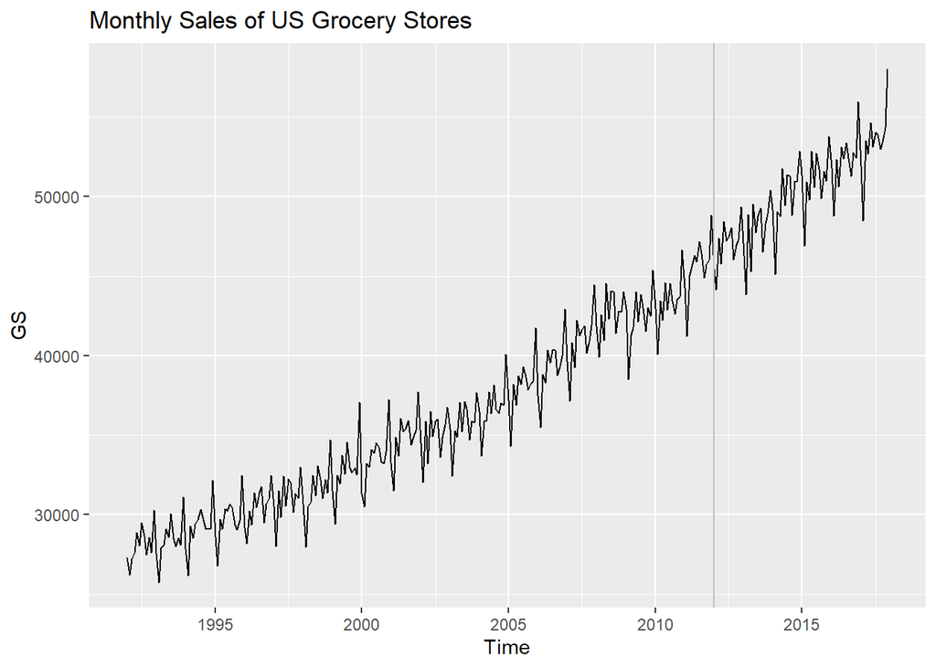

```r
tr <- window(GS, end=c(2011,12))
te <- window(GS, start=c(2012,1))

autoplot(GS) +
  geom_vline(xintercept=2012.0, color="gray") +
  ggtitle("Monthly Sales of US Grocery Stores")
```

#### 1. Holt-Winters Model Analysis: part I:

#### Use the **ets(…)** function to fit a Holt-Winters exponential smoothing model with additive errors to the training sales data. Leave it up to the **ets(…)** function to decide if a damping parameter is necessary (i.e., do not specify the damped directive. Name this model **f.HW**, and report the model details including the optimized value of each of the constants and smoothing parameters required by the model, the *AIC*, *AICc* and *BIC* values, as well as the in-sample fitting indicators. *

```r
f.HW <- ets(tr, model="AZZ")   # Not sure if it should be AAZ , as the results will be similar to multiplcative
print("Model Details:")
```

```
## [1] "Model Details:"
```

```r
summary(f.HW)
```

```
## ETS(A,Ad,A)
##
## Call:
##  ets(y = tr, model = "AZZ")
##
##   Smoothing parameters:
##     alpha = 0.1459
##     beta  = 0.1458
##     gamma = 1e-04
##     phi   = 0.8296
##
##   Initial states:
##     l = 27975.7976
##     b = 56.6232
##     s = 2422.541 -171.9733 -150.2665 -813.5405 576.5694 1151.272
##            23.4452 1149.711 -759.5466 33.5565 -2880.456 -581.3123
##
##   sigma:  539.2869
##
##      AIC     AICc      BIC
## 4353.040 4356.135 4415.692
##
## Training set error measures:
##                    ME     RMSE      MAE       MPE     MAPE      MASE       ACF1
## Training set 88.18648 519.8364 408.3749 0.2297179 1.164242 0.4025102 -0.2909248
```

#### Use the **forecast(…)** function to obtain a **72-month-ahead** forecast (i.e., forecast the entire testing or hold-out dataset), name this forecast **fc.HW** and plot it (i.e. call the **autoplot(fc.HW)** function); overlay on this plot the actual sales observed during this testing period (i.e. call the function **+ autolayer(te, series = “Actual Sales”)** to overlay the testing set data).*

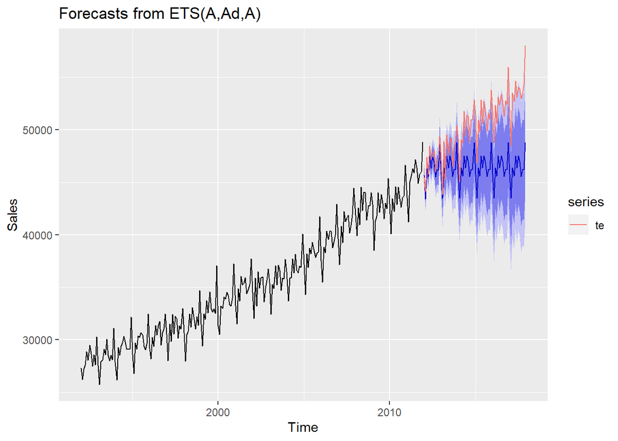

```r
#Forecase takes h as number of periods the sales to be forecasted
fc.HW<-f.HW %>%
  forecast(h=72)
fc.HW %>%
  autoplot(ylab="Sales") +
  ylab("Sales") +
  autolayer(te)
```

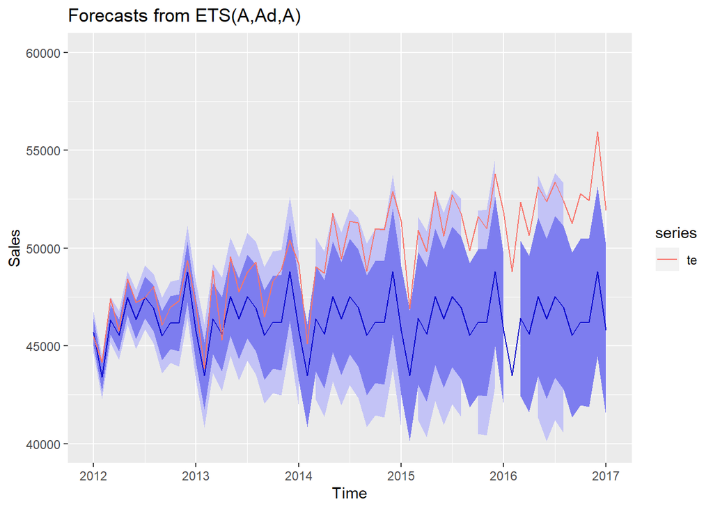

```r
#Zoom the forecasted period
fc.HW  %>%
  autoplot(ylab="Sales") +
  ylab("Sales") +
  xlim(2012,2017) +
  ylim(40000,60000)+
  autolayer(te)
```

###### Calculate the *in-sample* and *out-of-sample* fit statistics. You can obtain the in-sample and out-of-sample fit metrics comparison by calling the function **accuracy(fc.HW, te)**

```r
print("In-sample and out-of sample accuracy:")
```

```
## [1] "In-sample and out-of sample accuracy:"
```

```r
print(accuracy(fc.HW,te))
```

```
##                      ME      RMSE       MAE       MPE     MAPE      MASE
## Training set   88.18648  519.8364  408.3749 0.2297179 1.164242 0.4025102
## Test set     3914.49248 4589.1061 3928.8918 7.5627144 7.594424 3.8724692
##                    ACF1 Theil's U
## Training set -0.2909248        NA
## Test set      0.8546705  1.854899
```

#### 2. Holt-Winters Model Analysis: part II:

- Optimize the parameters of a Holt-Winters model disallowing damping of growth (i.e., use the **damped = FALSE** directive in the call to the **ets(…)** function). Call the fitted model **f.HW2**, and report the model details including the optimized value of each of the constants and smoothing parameters required by the model, the *AIC, AICc* and *BIC* values, as well as the in-sample fitting indicators.*

```r
f.HW2 <- ets(tr, model="AZZ",damped=FALSE)
print("Model Details:")
```

```
## [1] "Model Details:"
```

```r
summary(f.HW2)
```

```
## ETS(A,A,A)
##
## Call:
##  ets(y = tr, model = "AZZ", damped = FALSE)
##
##   Smoothing parameters:
##     alpha = 0.2635
##     beta  = 0.0051
##     gamma = 1e-04
##
##   Initial states:
##     l = 27974.1193
##     b = 51.8809
##     s = 2427.198 -178.9884 -144.9864 -826.3089 583.6564 1151.71
##            19.3497 1150.373 -757.9677 30.1697 -2865.102 -589.1037
##
##   sigma:  542.938
##
##      AIC     AICc      BIC
## 4355.353 4358.109 4414.524
##
## Training set error measures:
##                    ME    RMSE      MAE        MPE     MAPE      MASE       ACF1
## Training set 41.56951 524.528 406.0665 0.09009096 1.159924 0.4002351 -0.2788064
```

###### Obtain a 72-month-ahead forecast, name this forecast **fc.HW2** and plot it.

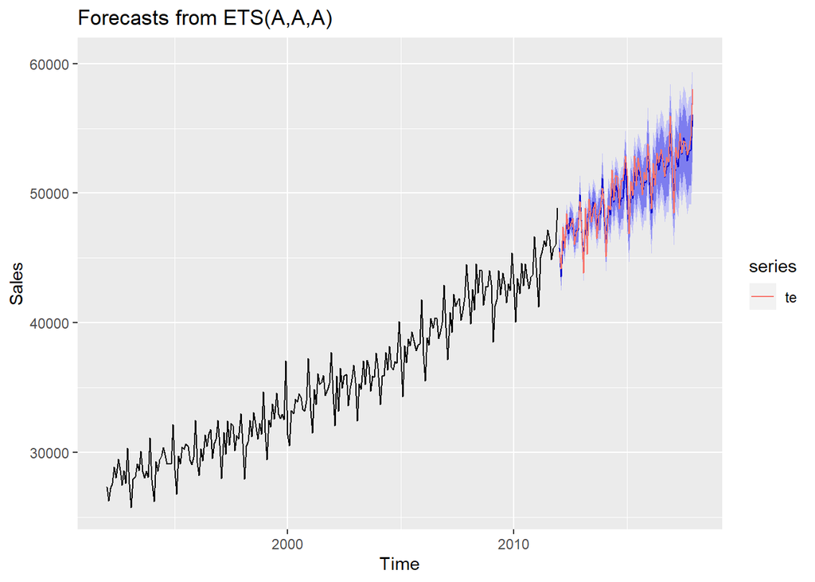

```r
#Forecase takes h as number of periods the sales to be forecasted
fc.HW2<-f.HW2 %>%
  forecast(h=72)
fc.HW2 %>%
  autoplot(ylab="Sales") +
  ylab("Sales") +
  autolayer(te)
```

###### Calculate the *in-sample* and *out-of-sample* fit statistics of the **fc.HW2** forecast.

```r
print("In-sample and out-of sample accuracy:")
```

```
## [1] "In-sample and out-of sample accuracy:"
```

```r
print(accuracy(fc.HW2,te))
```

```
##                     ME     RMSE      MAE        MPE     MAPE      MASE
## Training set  41.56951 524.5280 406.0665 0.09009096 1.159924 0.4002351
## Test set     291.54776 757.7241 591.5288 0.53593606 1.173839 0.5830339
##                     ACF1 Theil's U
## Training set -0.27880638        NA
## Test set     -0.09174218 0.3159545
```

#### 3. Optimal ETS Model Selection:

###### Now we call the **ets(…)** function using the **model=”ZZZ”** directive to optimize the model selection including multiplicative models (i.e., set the **restrict=FALSE** option). Call the fitted model **f.O**, and report the model details, the *AIC, AICc* and *BIC* values, as well as the in-sample fitting indicators.

```r
f.O <- ets(tr, model="ZZZ", restrict =FALSE)
summary(f.O)
```

```
## ETS(M,A,A)
##
## Call:
##  ets(y = tr, model = "ZZZ", restrict = FALSE)
##
##   Smoothing parameters:
##     alpha = 0.2328
##     beta  = 0.0041
##     gamma = 1e-04
##
##   Initial states:
##     l = 27978.8076
##     b = 56.015
##     s = 2378.258 -169.2943 -144.1528 -796.7364 575.0091 1156.585
##            38.1926 1153.63 -757.9354 35.1323 -2768.678 -700.0095
##
##   sigma:  0.0154
##
##      AIC     AICc      BIC
## 4352.540 4355.297 4411.711
##
## Training set error measures:
##                    ME     RMSE      MAE        MPE    MAPE      MASE       ACF1
## Training set 45.28612 529.6129 407.5492 0.09263676 1.15639 0.4016964 -0.2314272
```

###### Obtain a 72-month-ahead forecast, name this forecast **fc.O** and plot it.

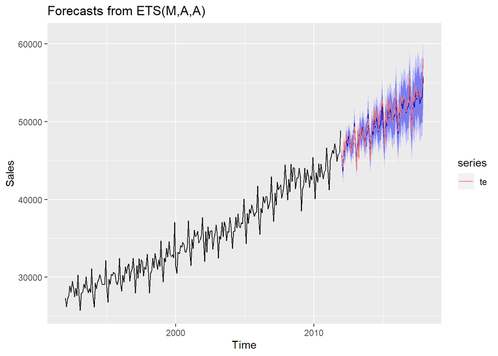

```r
#Forecase takes h as number of periods the sales to be forecasted
fc.0<- f.O %>%
  forecast(h=72)
fc.0 %>%
  autoplot(ylab="Sales") +
  ylab("Sales") +
  autolayer(te)
```

###### Calculate the *in-sample* and *out-of-sample* fit statistics of the **fc.O** forecast.

```r
print("In-sample and out-of sample accuracy:")
```

```
## [1] "In-sample and out-of sample accuracy:"
```

```r
print(accuracy(fc.0,te))
```

```
##                     ME     RMSE      MAE        MPE     MAPE      MASE
## Training set  45.28612 529.6129 407.5492 0.09263676 1.156390 0.4016964
## Test set     409.13236 836.6561 666.9141 0.76421242 1.316576 0.6573366
##                     ACF1 Theil's U
## Training set -0.23142723        NA
## Test set     -0.07587836 0.3474461
```

###### Compare the out-of-sample accuracy metrics of **fc.HW**, **fc.HW2** and **fc.O**. Compare the *AIC AICc* and *BIC* of models **f.HW**, **f.HW2** and **f.O**. Which model/method would you choose for forecasting?

- The model with additive error has slightly better out-of-sample errors i.e. fc.HW2 (lower errors)
- However, the AIC, BIC & AICc is almost similar for both the models
- As it is evident from the trend that the seasonal peaks are not getting exaggerated with time even though there is an upward trend in the data.
- Hence, out-of sample measure is giving us the better estimate for the model with additive errors. Hence, I would choose the model with additive errors

#### 4. Optimized model using BoxCox-Transformed Data:

- Select the best value of the “*lambda*” parameter for the BoxCox transformation over the training set **tr**, and then use the **ets(…)** function to optimize the model selection as you did in Question (3). Call the fitted model **fB.O**, and report the model details, the *AIC, AICc* and *BIC* values, as well as the in-sample fitting indicators.

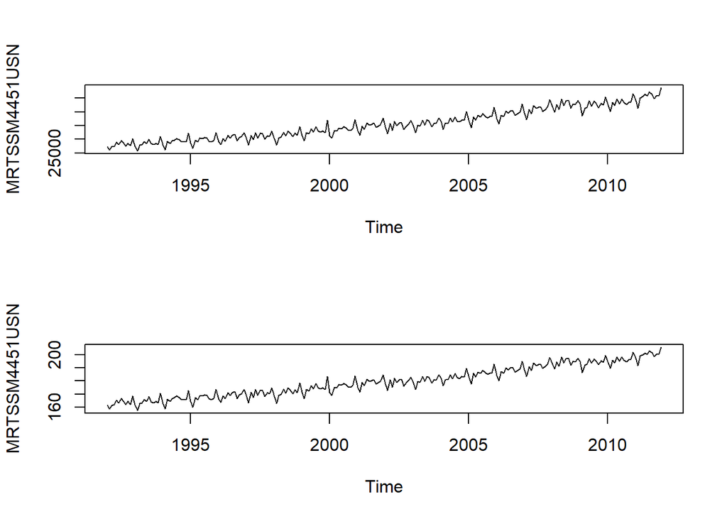

```r
# Optimized Model with BoxCox Transformation
L <- BoxCox.lambda(tr)
z <- BoxCox(tr,L)
par(mfrow=c(2,1))
plot(tr)
plot(z)
```

```r
par(mfrow=c(1,1))
```

```r
# Forecast Based on BC Transformation
fB.0 <- ets(tr, model="ZZZ", restrict =FALSE, lambda=L)
summary(fB.0)
```

```
## ETS(M,A,A)
##
## Call:
##  ets(y = tr, model = "ZZZ", lambda = L, restrict = FALSE)
##
##   Box-Cox transformation: lambda= 0.4125
##
##   Smoothing parameters:
##     alpha = 0.2389
##     beta  = 0.0025
##     gamma = 1e-04
##
##   Initial states:
##     l = 162.7329
##     b = 0.129
##     s = 5.2015 -0.3899 -0.324 -1.642 1.2789 2.4914
##            0.1262 2.3842 -1.5531 -7e-04 -6.3331 -1.2395
##
##   sigma:  0.0063
##
##      AIC     AICc      BIC
## 1388.401 1391.158 1447.572
##
## Training set error measures:
##                    ME     RMSE      MAE        MPE     MAPE      MASE
## Training set 41.79434 517.1069 396.1544 0.08768066 1.125411 0.3904652
##                    ACF1
## Training set -0.2464292
```

###### Obtain a 72-month-ahead forecast, name this forecast **fBc.O** and plot it.

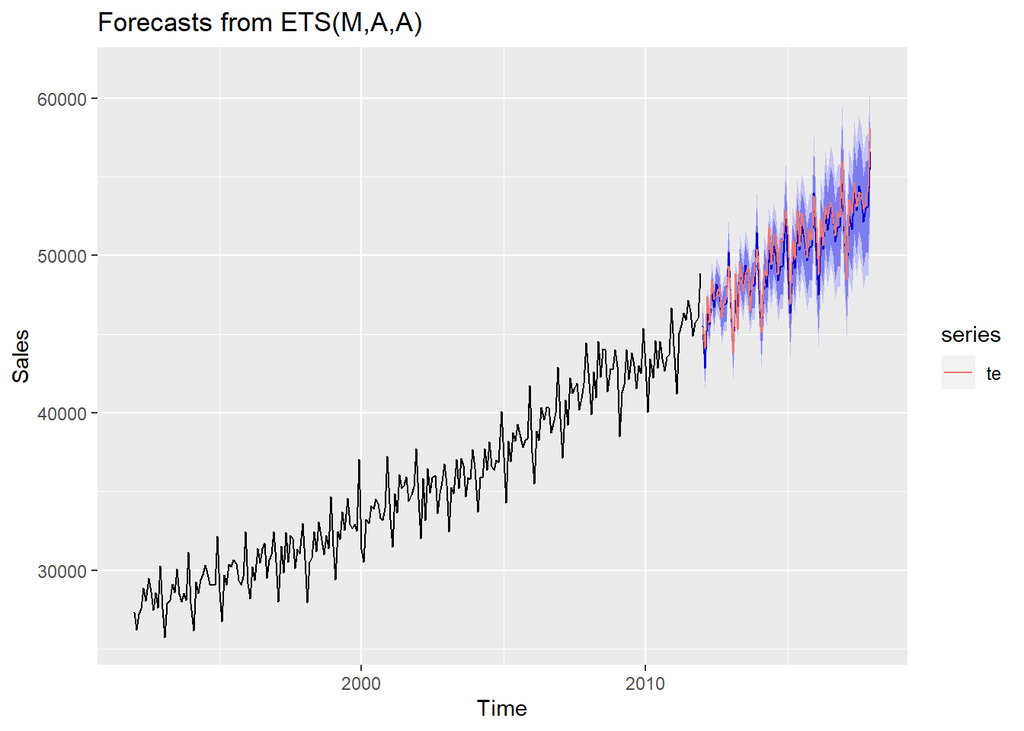

```r
fBc.0<- fB.0 %>%
  forecast(h=72)

fBc.0 %>%
  autoplot(ylab="Sales") +
  ylab("Sales") +
  autolayer(te)
```

###### Calculate the in-sample and out-of-sample fit statistics of the **fBc.O** forecast.

```r
print("In-sample and out-of sample accuracy:")
```

```
## [1] "In-sample and out-of sample accuracy:"
```

```r
print(accuracy(fBc.0,te))
```

```
##                     ME     RMSE      MAE        MPE     MAPE      MASE
## Training set  41.79434 517.1069 396.1544 0.08768066 1.125411 0.3904652
## Test set     493.71650 839.8616 681.9229 0.95817270 1.349351 0.6721299
##                     ACF1 Theil's U
## Training set -0.24642919        NA
## Test set     -0.02047443 0.3519391
```

###### Compare the in-sample and out-of-sample accuracy metrics of **fBc.O** and **fc.O**. Which model/method would you choose for forecasting? Why?

- Both fBc.O and fc.O have almost the same errors (MASE, MAPE etc.). However, AIC, AICc & BIC values are low for BoxCox transformation.
- Lower values indicate that the model is more likely to be true model. Hence, I would choose the model with BoxCox transformation
- Also, better performance of the model after boxcox transformation indicates that the iid is not normal and hence the transformation is making iid more normally distributed

#### 5. Optimized model with damping using BoxCox-Transformed Data:

###### Using the best value of “*lambda*” (i.e., the same you used in (4)), and set **damped=TRUE** in the **ets(…)** function. Name the fitted model **fB.OD** and report the model details and metrics.

```r
fB.OD <- ets(tr, model="ZZZ", restrict =FALSE, lambda=L,damped = TRUE)
summary(fB.OD)
```

```
## ETS(M,Ad,A)
##
## Call:
##  ets(y = tr, model = "ZZZ", damped = TRUE, lambda = L, restrict = FALSE)
##
##   Box-Cox transformation: lambda= 0.4125
##
##   Smoothing parameters:
##     alpha = 0.2183
##     beta  = 0.0409
##     gamma = 1e-04
##     phi   = 0.9654
##
##   Initial states:
##     l = 163.0008
##     b = 0.1061
##     s = 5.1552 -0.3949 -0.2677 -1.6903 1.258 2.5866
##            0.1037 2.3685 -1.5927 -0.0424 -6.2147 -1.2693
##
##   sigma:  0.0063
##
##      AIC     AICc      BIC
## 1395.301 1398.396 1457.953
##
## Training set error measures:
##                    ME    RMSE      MAE       MPE    MAPE      MASE       ACF1
## Training set 63.01338 522.228 406.8174 0.1563473 1.15368 0.4009751 -0.2444046
```

###### Now use the **forecast(…)** function to obtain a 72-month-ahead forecast, name this forecast **fBc.OD** and plot it.

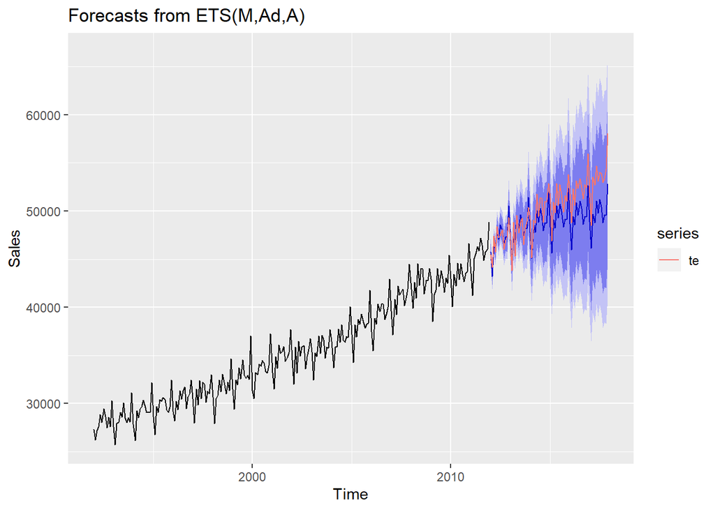

```r
fBc.OD<- fB.OD %>%
  forecast(h=72)

fBc.OD %>%
  autoplot(ylab="Sales") +
  ylab("Sales") +
  autolayer(te)
```

###### Use the function **accuracy(…)** to calculate the in-sample and out-of-sample fit statistics of the **fBc.OD** forecast.

```r
print("In-sample and out-of sample accuracy:")
```

```
## [1] "In-sample and out-of sample accuracy:"
```

```r
print(accuracy(fBc.OD,te))
```

```
##                      ME     RMSE       MAE       MPE    MAPE      MASE
## Training set   63.01338  522.228  406.8174 0.1563473 1.15368 0.4009751
## Test set     1522.59359 2180.261 1765.4273 2.8931232 3.40745 1.7400741
##                    ACF1 Theil's U
## Training set -0.2444046        NA
## Test set      0.7565656 0.8769238
```

#### 6. In an effort to improve forecasts, we want to assess the value of old information and discard the oldest segment of the information that does not have predictive value. To this end code and execute the following:

Evaluate the selection of a moving training set starting from 1992, 1993, etc all the way to starting in 2006, but in each case keep the end of the training set fixed at December of 2011. For each starting year:

- Select the value of the Box “lambda” for each training set
- Obtain an optimized model using all the **ets**-options that you consider pertinent based on your analysis in previous questions.
- Extract the in-sample *RMSE*
- Based on *RMSE*, select the best starting year for the training set
- Report the lowest *RMSE* and the starting year the generates it
- Create a “reduced” training set starting the year you identified above, and terminating in December of 2011. Name this reduced training set **trr**.

```r
#Loop for running different models with start years between 1992 and 2006
df<-data.frame(year=numeric(),RMSE=numeric())
i=1992
for(i in 1992:2006)
{
  tr <- window(GS, start=c(i,1),end=c(2011,12))
  L <- BoxCox.lambda(tr)
  optm_model <- ets(tr,model="ZZZ", damped=FALSE, lambda=L)
  print('starting year: ')
  print(i)
  summary(optm_model)
  df<-rbind(df,c(i,accuracy(optm_model)[2]))
}
```

```
## [1] "starting year: "
## [1] 1992
## ETS(A,A,A)
##
## Call:
##  ets(y = tr, model = "ZZZ", damped = FALSE, lambda = L)
##
##   Box-Cox transformation: lambda= 0.4125
##
##   Smoothing parameters:
##     alpha = 0.2498
##     beta  = 1e-04
##     gamma = 1e-04
##
##   Initial states:
##     l = 162.6962
##     b = 0.1593
##     s = 5.2261 -0.3444 -0.295 -1.6955 1.2203 2.4809
##            0.0564 2.3694 -1.6201 0.0241 -6.2239 -1.1983
##
##   sigma:  1.1232
##
##      AIC     AICc      BIC
## 1388.541 1391.298 1447.712
##
## Training set error measures:
##                    ME     RMSE      MAE         MPE     MAPE    MASE       ACF1
## Training set 7.761307 514.7129 393.8358 -0.02156294 1.122848 0.38818 -0.2606177
## [1] "starting year: "
## [1] 1993
## ETS(A,A,A)
##
## Call:
##  ets(y = tr, model = "ZZZ", damped = FALSE, lambda = L)
##
##   Box-Cox transformation: lambda= 0.5056
##
##   Smoothing parameters:
##     alpha = 0.2543
##     beta  = 1e-04
```

[output cut: 391 more lines]

```
##
##   Initial states:
##     l = 900946.6205
##     b = 4547.1306
##     s = 74716.18 -2103.218 -6442.896 -34682.6 19179.63 34895.22
##            -1530.466 46404.07 -24968.78 -640.243 -98696.98 -6129.92
##
##   sigma:  19101.15
##
##      AIC     AICc      BIC
## 1743.306 1754.639 1782.009
##
## Training set error measures:
##                    ME   RMSE      MAE        MPE      MAPE      MASE       ACF1
## Training set -58.9392 539.28 398.9102 -0.1600057 0.9475425 0.2773644 -0.1570471
```

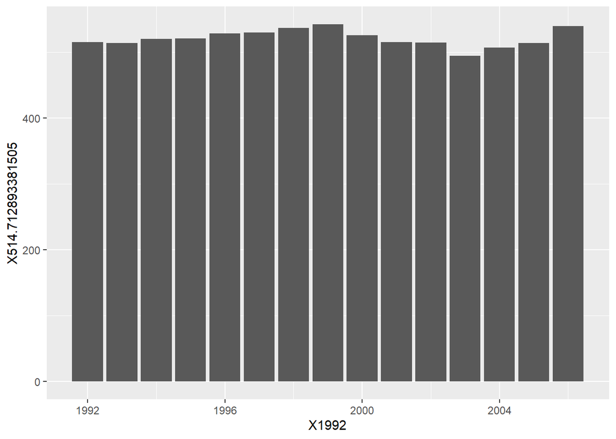

```r
#Plotting RMSE for all start years
library(ggplot2)
ggplot(df,aes(x=X1992,y=X514.712893381505))+geom_col()
```

```r
#Minimum value of RMSE is observed at year 2003

#Creating reduced dataset
trr <- window(GS, start=c(2003,1),end=c(2011,12))
```

#### 7. Fitting a model on the reduced training dataset:

###### Figure out the best value of the BoxCox “*lambda*” value for the reduced training data set **trr**, and fit the best *ETS* model to this data. Report the model parameters and metrics. Name this model **f**.

```r
#Fit the best model on reduced training set after Box-Cox transformation
L <- BoxCox.lambda(trr)
f <- ets(trr,model="ZZZ", damped=FALSE, lambda=L)
summary(f)
```

```
## ETS(A,A,A)
##
## Call:
##  ets(y = trr, model = "ZZZ", damped = FALSE, lambda = L)
##
##   Box-Cox transformation: lambda= 0.5078
##
##   Smoothing parameters:
##     alpha = 0.3301
##     beta  = 1e-04
##     gamma = 1e-04
##
##   Initial states:
##     l = 399.4077
##     b = 0.5583
##     s = 12.8566 -0.5962 -0.7976 -5.2921 2.9091 6.4086
##            -0.0603 7.2797 -4.1468 -0.0692 -17.3077 -1.1841
##
##   sigma:  2.8766
##
##      AIC     AICc      BIC
## 750.5826 757.3826 796.1789
##
## Training set error measures:
##                     ME     RMSE      MAE         MPE      MAPE      MASE
## Training set -3.339608 494.2241 372.3265 -0.02329248 0.9209826 0.2747818
##                    ACF1
## Training set -0.1682316
```

###### Obtain a 72-month-ahead forecast, name this forecast **fc** and plot it.

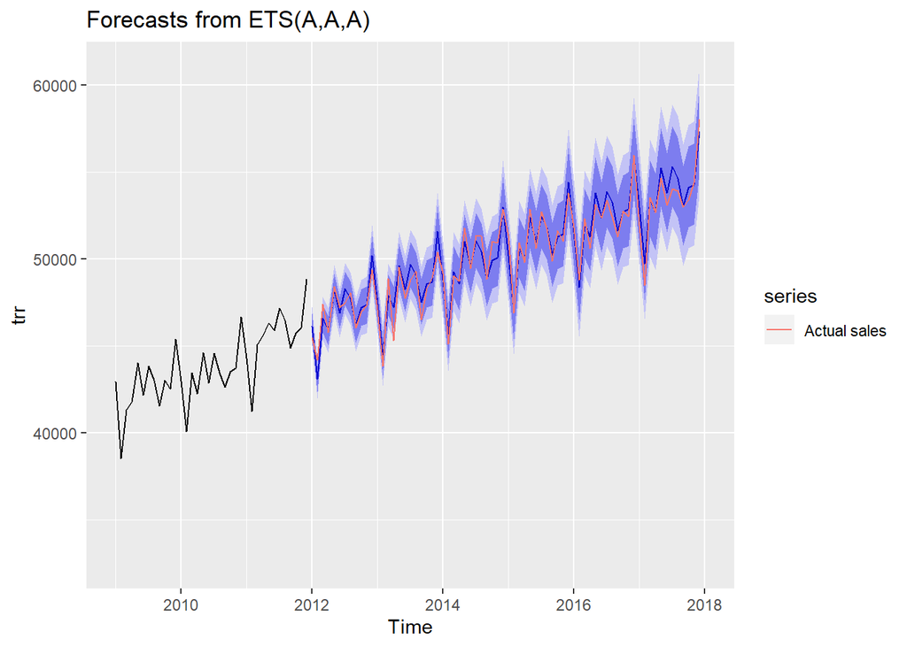

```r
fc=forecast(f,h=72)
autoplot(fc)+autolayer(te,series = 'Actual sales')+xlim(2009,2018)
```

###### * Calculate the *in-sample* and *out-of-sample* fit statistics of the **fc** forecast.

```r
accuracy(fc,te)
```

```
##                       ME     RMSE      MAE         MPE      MAPE      MASE
## Training set   -3.339608 494.2241 372.3265 -0.02329248 0.9209826 0.2747818
## Test set     -129.767374 630.1937 498.3861 -0.26555714 0.9995910 0.3678155
##                     ACF1 Theil's U
## Training set -0.16823162        NA
## Test set      0.03218511  0.262839
```

###### * Is the in-sample *AICc* for model **f.O** comparable with the in-sample *AICc* for model **f**? Explain.

- Yes. As AICc adjusts for the sampel size, it is scaled for all the models. On the other hand, AIC is adjusted for sample size and hence can not be used across different datasets. Hence, AICc is a better for comparing f.O & f models

###### * Is the in-sample *MASE* for model **f.O** comparable with the in-sample *MASE* for model **f**? Explain.

- No. MASE can not be compared across 2 different datasets as the data points are different for these models. It is a good measure to compare out-of sample validation using the 2 models with different datasize

###### * Is the *out-of-sample RMSE* for forecast **fc.O** comparable with the *out-of-sample RMSE* for forecast **fc**? Explain. Is the **fc** forecast truly an *out-of-sample* forecast? Explain.

- Yes, the out-of-sample RMSEs for these 2 models are comparable as they are tested on the same dataset. It is a measure of actual vs predicted values for the same dataset and hence could be compared for these 2 models

#### 8. Aggregate Sales Forecast for 2018—2022:

###### Next we need to prepare a monthly sales forecast through December 2022. To this end we first set the training set to include all the data starting from the year we selected in (6) through December 2017. Select the *ETS* model you analyzed in (7), and fit the best parameters to that model. Name the resulting model **ff**.

###### Compare the in-sample accuracy of fit statistics of **ff** with those of model **f**.

```r
tr_new <- window(GS, start=c(2003,1),end =c(2017,12))
L <- BoxCox.lambda(tr_new)
ff <- ets(tr_new,model="ZZZ", damped=FALSE, lambda=L)
summary(ff)
```

```
## ETS(A,A,A)
##
## Call:
##  ets(y = tr_new, model = "ZZZ", damped = FALSE, lambda = L)
##
##   Box-Cox transformation: lambda= 0.4171
##
##   Smoothing parameters:
##     alpha = 0.2862
##     beta  = 1e-04
##     gamma = 1e-04
##
##   Initial states:
##     l = 186.8601
##     b = 0.2088
##     s = 4.6722 -0.0919 -0.1955 -2.1709 1.2478 2.2532
##            -0.1071 2.8701 -1.8022 0.3446 -6.6175 -0.4028
##
##   sigma:  1.1024
##
##       AIC      AICc       BIC
##  987.0658  990.8435 1041.3460
##
## Training set error measures:
##                      ME     RMSE      MAE         MPE      MAPE      MASE
## Training set -0.5825283 539.5379 424.0555 -0.01688554 0.9559198 0.3152885
##                    ACF1
## Training set -0.1755278
```

###### Obtain a 60-month-ahead forecast, name this forecast **ffc** and plot it (this time do not include the xlim limits on the forecast plot.

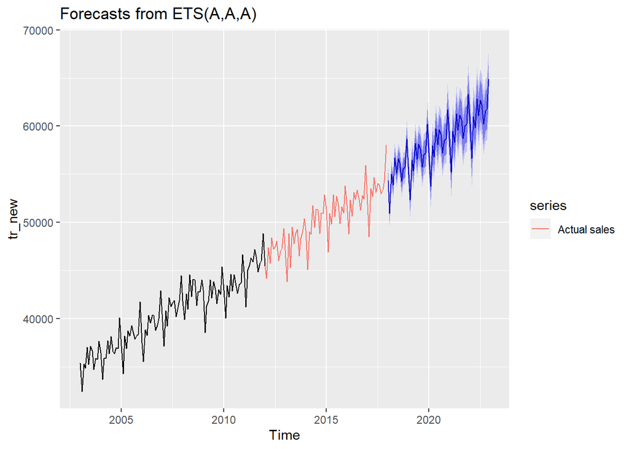

```r
# 60 month forecast:
ffc=forecast(ff,h=60)
autoplot(ffc)+autolayer(te,series = 'Actual sales')
```

###### Based on your analysis what would you expect the out-of-sample (i.e., the actual) *MAPE* be over the next five years? Why?

- If the forecast is not damped, then the MAPE will be around 0.9, which is along the line of MAPE obtained so far. However, it depends on the conditions in the specific year, if any event or additional promotion in launched in a particular year, then the sales might go up and the model would not be able to capture that variation.

###### You must plan for the expansion of capacity of your system. An important input in this process is the national-wide aggregate grocery store sales. What is the level of nationwide sales that will not be exceeded with a probability of 90%

```r
trr_nat=window(GS, start=c(2003,1),end=c(2017,12))
L-BoxCox.lambda(trr_nat)
```

```
## [1] 0
```

```r
f_nat=ets(trr_nat,model='ZZZ',restrict=FALSE,lambda = L)
summary(f_nat)
```

```
## ETS(A,A,A)
##
## Call:
##  ets(y = trr_nat, model = "ZZZ", lambda = L, restrict = FALSE)
##
##   Box-Cox transformation: lambda= 0.4171
##
##   Smoothing parameters:
##     alpha = 0.2862
##     beta  = 1e-04
##     gamma = 1e-04
##
##   Initial states:
##     l = 186.8601
##     b = 0.2088
##     s = 4.6722 -0.0919 -0.1955 -2.1709 1.2478 2.2532
##            -0.1071 2.8701 -1.8022 0.3446 -6.6175 -0.4028
##
##   sigma:  1.1024
##
##       AIC      AICc       BIC
##  987.0658  990.8435 1041.3460
##
## Training set error measures:
##                      ME     RMSE      MAE         MPE      MAPE      MASE
## Training set -0.5825283 539.5379 424.0555 -0.01688554 0.9559198 0.3152885
##                    ACF1
## Training set -0.1755278
```

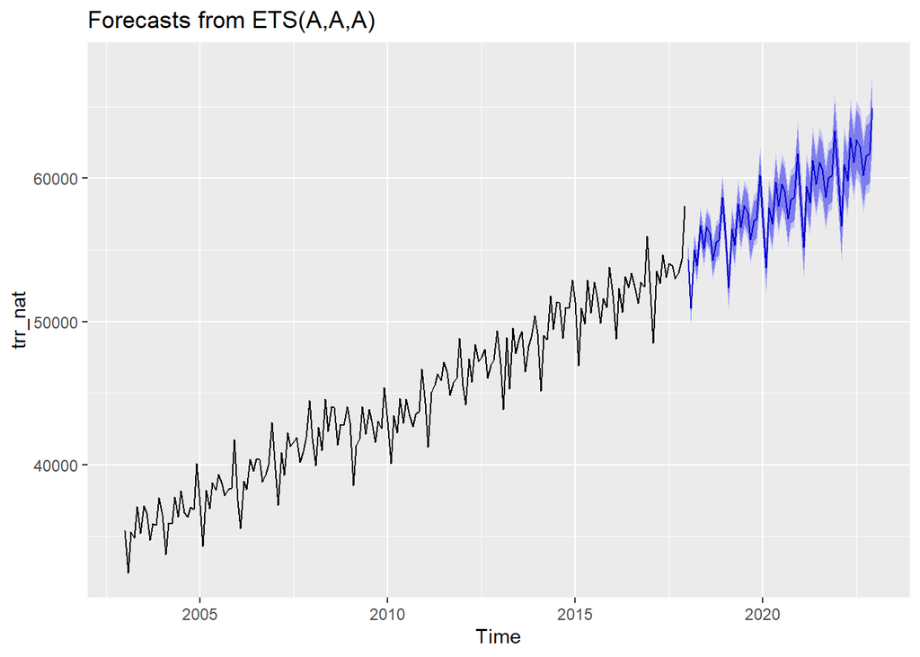

```r
f_nat_c=forecast(f_nat,h=60,level=c(80,90))
autoplot(f_nat_c)
```

```r
max(summary(f_nat_c)['Hi 80'])
```

```
##
## Forecast method: ETS(A,A,A)
##
## Model Information:
## ETS(A,A,A)
##
## Call:
##  ets(y = trr_nat, model = "ZZZ", lambda = L, restrict = FALSE)
##
##   Box-Cox transformation: lambda= 0.4171
##
##   Smoothing parameters:
##     alpha = 0.2862
##     beta  = 1e-04
##     gamma = 1e-04
##
##   Initial states:
##     l = 186.8601
##     b = 0.2088
##     s = 4.6722 -0.0919 -0.1955 -2.1709 1.2478 2.2532
##            -0.1071 2.8701 -1.8022 0.3446 -6.6175 -0.4028
##
##   sigma:  1.1024
##
##       AIC      AICc       BIC
##  987.0658  990.8435 1041.3460
##
## Error measures:
##                      ME     RMSE      MAE         MPE      MAPE      MASE
## Training set -0.5825283 539.5379 424.0555 -0.01688554 0.9559198 0.3152885
##                    ACF1
## Training set -0.1755278
##
## Forecasts:
##          Point Forecast    Lo 80    Hi 80    Lo 90    Hi 90
## Jan 2018       54338.06 53528.51 55154.71 53300.30 55387.51
## Feb 2018       50945.20 50134.41 51763.58 49905.94 51996.96
## Mar 2018       55010.79 54131.35 55898.51 53883.54 56151.67
## Apr 2018       53894.01 52995.07 54801.77 52741.84 55060.71
## May 2018       56732.22 55775.99 57697.94 55506.64 57973.44
```

[output cut: 40 more lines]

```
## Oct 2021       60027.22 58166.92 61921.76 57645.75 62465.08
## Nov 2021       60217.92 58337.76 62132.92 57811.08 62682.16
## Dec 2021       63301.49 61348.70 65290.03 60801.59 65860.29
## Jan 2022       60283.02 58369.28 62232.84 57833.30 62792.18
## Feb 2022       56675.61 54814.51 58573.03 54293.50 59117.56
## Mar 2022       60997.61 59038.50 62994.10 58489.89 63566.91
## Apr 2022       59811.21 57858.88 61801.42 57312.28 62372.53
## May 2022       62825.19 60799.68 64889.50 60232.51 65481.78
## Jun 2022       61105.06 59096.65 63152.71 58534.40 63740.36
## Jul 2022       62700.26 60645.47 64795.07 60070.21 65396.23
## Aug 2022       62202.99 60142.20 64304.37 59565.34 64907.49
## Sep 2022       60222.84 58185.63 62301.02 57615.54 62897.65
## Oct 2022       61566.11 59487.08 63686.89 58905.27 64295.72
## Nov 2022       61759.63 59661.58 63900.08 59074.49 64514.61
## Dec 2022       64888.50 62713.15 67107.22 62104.32 67744.12
```

```
## [1] 67107.22
```

- The nation-wide sales would not exceed 67107.22 with a probability of 90%